# Equity: ECE Seats

Brook Frye

2026-07-23

### Relationship between 3-4 year olds and total seats by PUMA

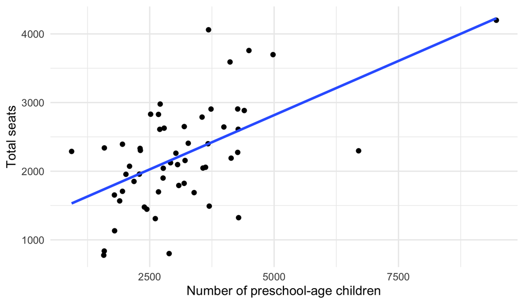

### Model

We take the log of total seats per preschool-age child and regress it on race/ethnicity shares and median household income at the PUMA level.

This model asks: after accounting for the size of the preschool-age population, are neighborhood racial/ethnic makeup or household income associated with having more or fewer seats?

$$\begin{aligned}
\log\left(\frac{\text{seats}}{\text{preschool-age children}}\right)
&= \beta_0 \\
&\quad + \beta_1(\text{Hispanic/Latino share}) \\
&\quad + \beta_2(\text{Black non-Hispanic share}) \\
&\quad + \beta_3(\text{Asian/API non-Hispanic share}) \\
&\quad + \beta_4(\text{median household income}) \\
&\quad + \epsilon
\end{aligned}$$

- **Asian/API non-Hispanic population share has the strongest relationship with number of ECE seats.** A 10 % point increase in Asian/API NH population share is associated with ~20% more seats.
- **Black non-Hispanic population share is also positively associated with seats per child**
- **Hispanic/Latino population share is not meaningfully associated with seats per child in this model.**
- **Median household income is not strongly associated with seats per child after accounting for neighborhood racial/ethnic makeup**

Model results: percent change in seats per preschool-age child

| Predictor | Percent change | 95% CI Lower | 95% CI Upper | P-value |
| --- | --- | --- | --- | --- |
| Intercept | -38.0 | -68.4 | 21.5 | 0.16 |
| 10 percentage-point inc Hispanic/Latino | 0.5 | -6.3 | 7.8 | 0.88 |
| 10 percentage-point inc Black NH | 6.5 | -0.4 | 13.9 | 0.07 |
| 10 percentage-point inc Asian/API NH | 20.2 | 8.8 | 32.7 | 0.00 |
| $10,000 inc Median hh income | -3.4 | -7.5 | 0.9 | 0.12 |

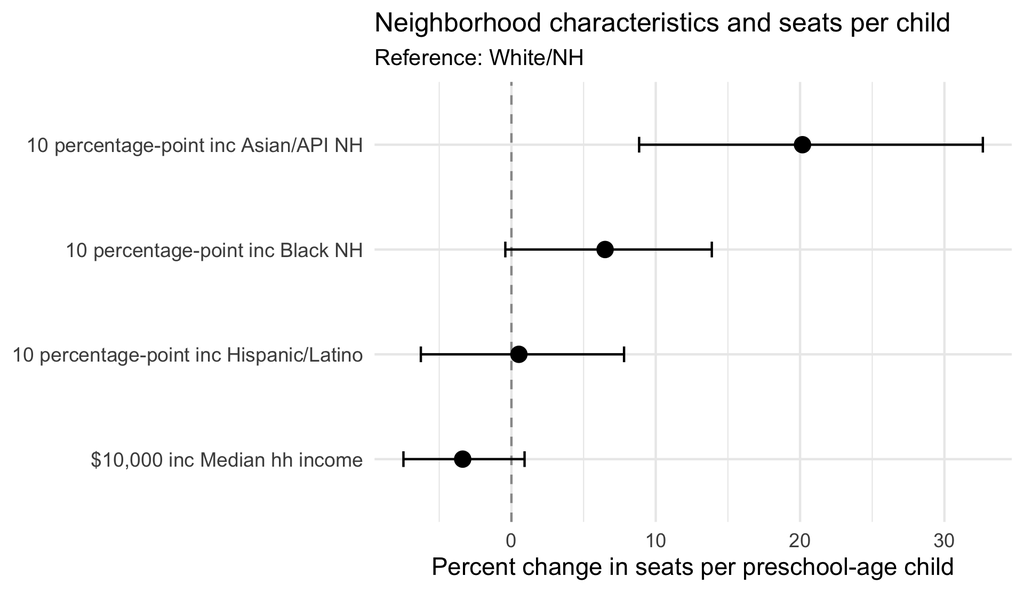

[interactive chart not shown]

### Model Diagnostics

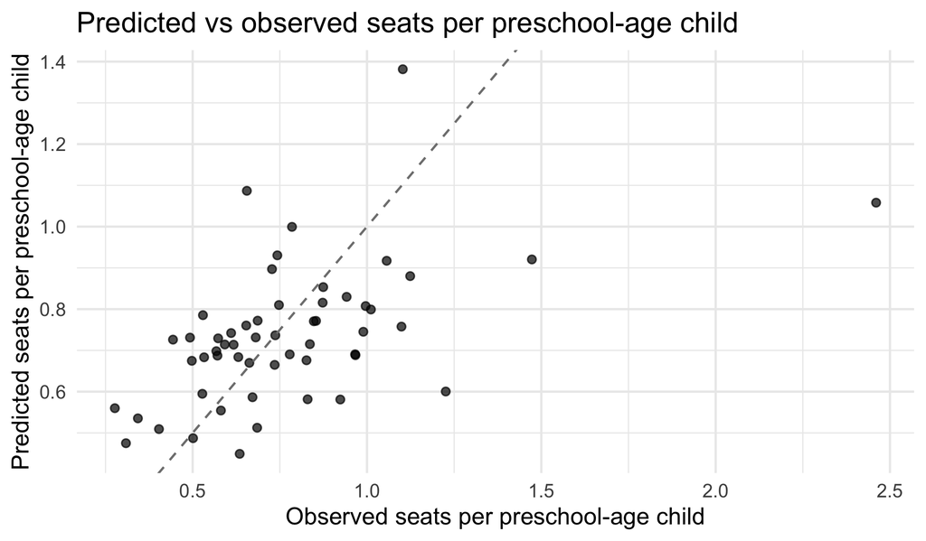

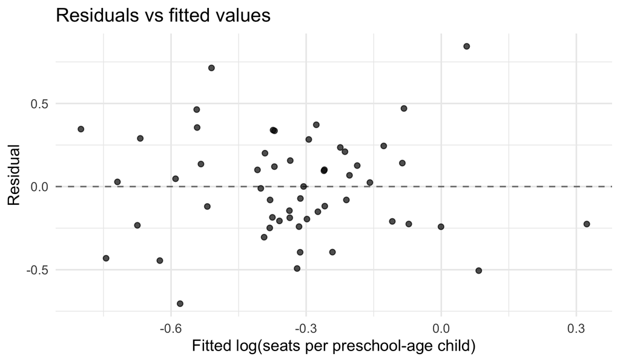

### Robustness Checks

Dropping median HH income from model, we see that income attenuates the NH Black category, suggesting that part of the observed association between Black population share and seats/child is explained by differences in neighborhood income.For both models, Asian/API NH remains significant and suggests that in these neighborhoods with higher shares of Asian/API NH have more seats, regardless of median income.

Percent change in seats per preschool-age child, with and without income adj

| Predictor | Race/ethnicity only model Without income | Race/ethnicity only model P-value without income | Race/ethnicity + income model With income | Race/ethnicity + income model P-value with income |
| --- | --- | --- | --- | --- |
| Hispanic/Latino | 4.4% (-0.8, 9.9) | 0.095 | 0.5% (-6.3, 7.8) | 0.883 |
| Black NH | 9.8% (3.8, 16.1) | 0.001 | 6.5% (-0.4, 13.9) | 0.066 |
| Asian/API NH | 23.4% (12.3, 35.6) | <0.001 | 20.2% (8.8, 32.7) | <0.001 |
| Median household income | NA | NA | -3.4% (-7.5, 0.9) | 0.118 |